# Econometrics BSEL ST 2017 Assignment 2

Vera Weidmann, Marvin Koenig, Sebastian Seck

submission to Prof. Qari

```r
library(foreign) #to read in the .dta format
library(stargazer)
library(dplyr)
library(ggplot2)
library(multcomp)
library(plm)
ksubs <- read.dta("401ksubs.dta")
wagepan <- read.dta("WAGEPAN.DTA")
```

## Task 1

```r
head(ksubs)
```

```
##   e401k    inc marr male age fsize  nettfa p401k pira     incsq agesq
## 1     0 13.170    0    0  40     1   4.575     0    1  173.4489  1600
## 2     1 61.230    0    1  35     1 154.000     1    0 3749.1128  1225
## 3     0 12.858    1    0  44     2   0.000     0    0  165.3282  1936
## 4     0 98.880    1    1  44     2  21.800     0    0 9777.2539  1936
## 5     0 22.614    0    0  53     1  18.450     0    0  511.3930  2809
## 6     0 15.000    1    0  60     3   0.000     0    0  225.0000  3600
```

First of all, as the exercise description requires just the data for married couples without children (marr=1, fsize = 2), we have to filter our data. This is done by using the r-package dplyr.

The new data table is saved in the new data frame: ksubs_1

```r
ksubs_1 <- ksubs %>%
  filter(marr ==1 & fsize == 2)
```

#### 1(a) Youngest age of the household head

```r
summary(ksubs_1$age)
```

```
##    Min. 1st Qu.  Median    Mean 3rd Qu.    Max.
##   25.00   32.00   47.00   45.13   56.00   64.00
```

The youngest age of the household head in this sample is 25.

```r
ksubs_1_age <- ksubs_1 %>%
  group_by(age) %>%
  summarise(n=n()) %>%
  arrange(age)

head(ksubs_1_age)
```

```
## # A tibble: 6 × 2
##     age     n
##   <int> <int>
## 1    25    29
## 2    26    52
## 3    27    55
## 4    28    55
## 5    29    55
## 6    30    51
```

```r
paste("Number of household heads at the age of", ksubs_1_age[1,1],":", ksubs_1_age[1,2])
```

```
## [1] "Number of household heads at the age of 25 : 29"
```

```r
paste("Number of all households in the restricted dataset:", nrow(ksubs_1))
```

```
## [1] "Number of all households in the restricted dataset: 1494"
```

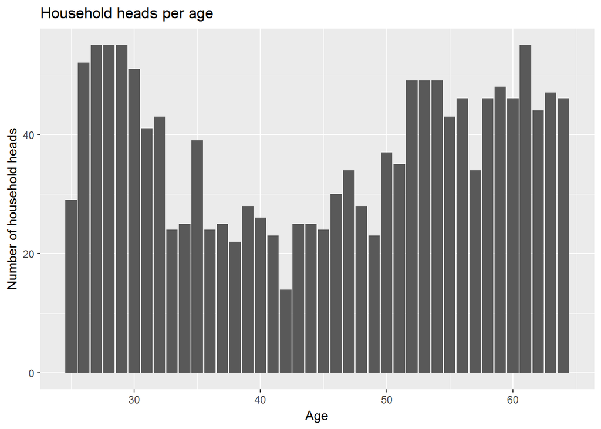

```r
ggplot(ksubs_1_age,aes(age,n))+geom_col()+labs(
      y="Number of household heads",
      x="Age",
      title="Household heads per age")
```

So, 29 households heads are at the age of 25. In total, we have 1494 married households without children.

#### 1(b) Model & Coefficients (1)

The regression $nettfa = \beta_0 + \beta_1 * inc + \beta_2 * age + \beta_3 * age^2 + u$ gives information about the relationship between the independet variables, also called predictor, ($inc, age, age^2$) and the dependent variable ($nettfa$)

As this model is a level-level model, one unit increase of one of the predictors (while holding the others fix) will lead to an increase in nettfa by the predictors’ coefficient.

$\frac{\delta nettfa}{\delta inc}=\beta_1$  
$\frac{\delta nettfa}{\delta age}=\beta_2 + 2*\beta_3*age$

$\beta_0$ is the intercept of the model. This covers the value of nettfa when all predictors are equal to 0.

#### 1(c) Model & Coefficients (2)

```r
mod1c <- lm(nettfa ~ inc + age + agesq, data = ksubs_1)
summary(mod1c)
```

```
##
## Call:
## lm(formula = nettfa ~ inc + age + agesq, data = ksubs_1)
##
## Residuals:
##     Min      1Q  Median      3Q     Max
## -518.93  -29.32   -7.19   15.66 1448.02
##
## Coefficients:
##              Estimate Std. Error t value Pr(>|t|)
## (Intercept) -39.74990   33.15342  -1.199   0.2307
## inc           1.33317    0.07807  17.076   <2e-16 ***
## age          -1.56905    1.60697  -0.976   0.3290
## agesq         0.03647    0.01802   2.023   0.0432 *
## ---
## Signif. codes:  0 '***' 0.001 '**' 0.01 '*' 0.05 '.' 0.1 ' ' 1
##
## Residual standard error: 81.65 on 1490 degrees of freedom
## Multiple R-squared:  0.2043, Adjusted R-squared:  0.2027
## F-statistic: 127.5 on 3 and 1490 DF,  p-value: < 2.2e-16
```

```r
paste("n:", nrow(ksubs_1))
```

```
## [1] "n: 1494"
```

As mentioned in 2(b) the intercept of the model with the value of -39.74 is the value of nettfam while predictors are equal to 0. If one predictor is increased by one, e.g. one unit (1,000 dollars) more in inc, that nettfa will increase by $\beta = 1.3$ (1,300 dollars). The increase of one change in age depends on the value of age itself as the regression model included $age^2$.

The calculation of the turnaround point is $x = | \frac{\beta_2}{2*\beta_3} |= |\frac{-1.56905}{2*0.03647}| = 21.51$. This means starting with an age of 22 the nettfam will increase, before 22 the nettfam will decrease.

The partial effect of age on nettfa for someone who is aged 30 years is:
$$\frac{\delta nettfa}{\delta age}=\beta_2 + 2*\beta_3*age = -1.56905 + 2*0.03647*30 = 0.61915 = 619\space Dollars$$

#### 1(d) Regression for age of 25

$nettfa = \beta_0 + \beta_1 * inc + \beta_2 * age + \beta_3 * age^2 + u$

$\frac{\delta nettfa}{\delta age}=\beta_2 + 2*\beta_3*age$ ; (age=25)

$\theta_2 = \beta_2 + \beta_3 *2* 25$  
$\Leftrightarrow \beta_2 = \theta_2 - \beta_3 *2*25$

Insert in equation from 1(b):

$nettfa = \beta_0 + \beta_1 * inc + (\theta_2 - \beta_3 *2*25) * age + \beta_3 * age^2 + u$

$nettfa = \beta_0 + \beta_1 * inc + \theta_2 * age - \beta_3 *2*25 * age + \beta_3 * age^2 + u$

$nettfa = \beta_0 + \beta_1 * inc + \theta_2 * age + \beta_3 (age^2 - 2*25*age) + u$

The intercept of the regression model for household heads with age 25 is shifted by the effect of $25^2 = 625$). Therefore, we adjust $\beta_0$ to $\alpha_0$.

$nettfa = \alpha_0 + \beta_1 * inc + \theta_2 * age + \beta_3 (age^2-2*25*age+625) + u$

$nettfa = \alpha_0 + \beta_1 * inc + \theta_2 * age + \beta_3 (age-25)^2 + u$

```r
ksubs_1$age25 <- (ksubs_1$age-25)^2

mod1d <- lm(nettfa ~ inc + age + age25, data = ksubs_1)
(sum_mod1d <- summary(mod1d))
```

```
##
## Call:
## lm(formula = nettfa ~ inc + age + age25, data = ksubs_1)
##
## Residuals:
##     Min      1Q  Median      3Q     Max
## -518.93  -29.32   -7.19   15.66 1448.02
##
## Coefficients:
##              Estimate Std. Error t value Pr(>|t|)
## (Intercept) -62.54144   22.49902  -2.780  0.00551 **
## inc           1.33317    0.07807  17.076  < 2e-16 ***
## age           0.25427    0.71706   0.355  0.72294
## age25         0.03647    0.01802   2.023  0.04321 *
## ---
## Signif. codes:  0 '***' 0.001 '**' 0.01 '*' 0.05 '.' 0.1 ' ' 1
##
## Residual standard error: 81.65 on 1490 degrees of freedom
## Multiple R-squared:  0.2043, Adjusted R-squared:  0.2027
## F-statistic: 127.5 on 3 and 1490 DF,  p-value: < 2.2e-16
```

$H_0: \theta_2 =0$ ; (two-sided test, $\alpha = 0.05$)

As the p-value of $\theta_2 = 0.72294 > 0.05$, $H_0$ cannot be rejected. This variable might not have a significant effect on the dependent variable nettfam.

#### 1(e) Differences between $\beta_0$ and $\alpha_0$

```r
paste("the difference between the point estimates are:", round(mod1c$coefficients[1] - mod1d$coefficients[1],2))
```

```
## [1] "the difference between the point estimates are: 22.79"
```

In the first model (mod1b) the intercept presents the value of nettfa while all independet variables (inc and age) are equal to 0. As the age of one household head cannot be 0, the second equation (mod1d) makes more sense. By using (age-25) we are centering all variables around an age of 25 years. In that case, also the intercept is shifted by -22.79. So, it shows the effect of being 25 years old while other variables are equal to 0.

#### 1(f) The effect of age variable

```r
mod1f <- lm(nettfa ~ inc + age25, data = ksubs_1)
(sum_mod1f<- summary(mod1f))
```

```
##
## Call:
## lm(formula = nettfa ~ inc + age25, data = ksubs_1)
##
## Residuals:
##     Min      1Q  Median      3Q     Max
## -518.41  -29.16   -7.04   16.06 1448.52
##
## Coefficients:
##               Estimate Std. Error t value Pr(>|t|)
## (Intercept) -54.770819   5.097319  -10.74   <2e-16 ***
## inc           1.337345   0.077159   17.33   <2e-16 ***
## age25         0.042679   0.004228   10.10   <2e-16 ***
## ---
## Signif. codes:  0 '***' 0.001 '**' 0.01 '*' 0.05 '.' 0.1 ' ' 1
##
## Residual standard error: 81.62 on 1491 degrees of freedom
## Multiple R-squared:  0.2042, Adjusted R-squared:  0.2032
## F-statistic: 191.3 on 2 and 1491 DF,  p-value: < 2.2e-16
```

```r
stargazer(mod1d,mod1f, title = "Comparison of models mod1f and mod1d", type="html", model.names = FALSE,column.labels = c("mod1f", "mod1d"), column.separate = c(1,1), style = "qje")
```

**Comparison of models mod1f and mod1d**

[output not shown]

```r
paste("adjusted R_squared of Model 1d:", sum_mod1d$adj.r.squared)
```

```
## [1] "adjusted R_squared of Model 1d: 0.202702918091984"
```

```r
paste("adjusted R_squared of Model 1f:", sum_mod1f$adj.r.squared)
```

```
## [1] "adjusted R_squared of Model 1f: 0.203170418422801"
```

Looking at the adjusted $R^2$, it is seen that both models have a quite similar model quality. In both models nearly 20.3% of nettfa variance can be explained by the predictors. This measurement supports the low significance level of age in model 1d. As mentioned in 1d, $H_0: \space \theta_2 =0$ cannot be rejected. Therefore, the variable age can be omitted without losing model quality.

#### 1(g) Income of 50,000

```r
paste("The estimated  nettfa of an household which has an income of 50000 is:", round(sum_mod1f$coefficients[1,1] + sum_mod1f$coefficients[2,1] * 50 *1000,2))
```

```
## [1] "The estimated  nettfa of an household which has an income of 50000 is: 66812.47"
```

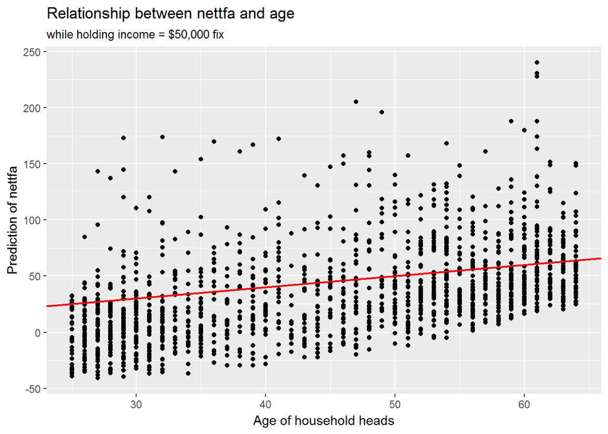

```r
ksubs_1$preds <- predict(inc=50, mod1f)

ggplot(ksubs_1,aes(x=age,y=preds))+geom_point()+geom_abline(col="red", size=0.8)+labs(
      x="Age of household heads",
      y="Prediction of nettfa",
      title="Relationship between nettfa and age",
      subtitle= "while holding income = $50,000 fix")
```

## Task 2 Heteroscedasticity

For task 2, we have to restrict our data to single individuals (fsize =1). The new data table is saved in the new data frame: ksubs_2

```r
ksubs_2 <- ksubs %>%
  filter(fsize == 1)
```

#### 2(a) Breusch-Pagan

```r
ksubs_2$age25 <- (ksubs_2$age-25)^2
mod2a <- lm(nettfa ~ inc + age25 + e401k, data = ksubs_2)
#summary(mod2a)
```

To check whether our data is underlying a heteroscedastic distribution, we test the residuals of the previous model. This can be made by running a regression on the squared error residuals:

$residuals^2 = \delta_0 + \delta_1 * inc + \delta_2 * (age-25) * \delta_3 *e401k + u$

```r
ksubs_2$residuals <- mod2a$residuals^2
mod2a_resid <- lm(residuals ~ inc + age25 + e401k, data = ksubs_2)
(sum_mod2a_resid <- summary(mod2a_resid))
```

```
##
## Call:
## lm(formula = residuals ~ inc + age25 + e401k, data = ksubs_2)
##
## Residuals:
##     Min      1Q  Median      3Q     Max
##  -11482   -2917   -1088     401 1234439
##
## Coefficients:
##              Estimate Std. Error t value Pr(>|t|)
## (Intercept) -3298.362   1650.979  -1.998   0.0459 *
## inc           120.427     45.785   2.630   0.0086 **
## age25           4.226      1.901   2.224   0.0263 *
## e401k        1030.691   1589.635   0.648   0.5168
## ---
## Signif. codes:  0 '***' 0.001 '**' 0.01 '*' 0.05 '.' 0.1 ' ' 1
##
## Residual standard error: 33360 on 2013 degrees of freedom
## Multiple R-squared:  0.006629,   Adjusted R-squared:  0.005148
## F-statistic: 4.478 on 3 and 2013 DF,  p-value: 0.003863
```

The null hypothesis tests if there is no difference in the variance of the residuals. So $H_0$ implies that our data is homoscedastic distributed (variance of 0).

$H_0:\delta_1 =0, \delta_2 =0, \delta_3 =0$ ; ($\alpha = 0.05$, two-sided)  
$H_1:\delta_1 \neq0, \delta_2 \neq0, \delta_3 \neq0$

Rejection rule: F > critical value

```r
paste("The f-statistic of model mod2a_resid is:", round(sum_mod2a_resid$fstatistic[1],2))
```

```
## [1] "The f-statistic of model mod2a_resid is: 4.48"
```

The critical value, which can be found in the f-table (on moodle) is 2.61 (using $ k=3, = 0.05, df = 2013$). This value can be also calculated via r:

```r
#(1-/alpha, k, n-k-1)
qf(0.95, 3, nrow(ksubs_2)-4)
```

```
## [1] 2.609323
```

As the calculated f-value of 4.48 is greater than the critical value of 2.61, we reject $H_0$. This means we have heteroscedasticity.

This can be also tested by the LM version:

$LM = n * R^2_u$

```r
LM = nrow(ksubs_2) * sum_mod2a_resid$r.squared
paste("The LM value is:", round(LM,2))
```

```
## [1] "The LM value is: 13.37"
```

As this value is far greater than the critical value of 2.61, we can reject $H_0$.

#### 2(b) WLS model

Heteroscedastic model:

$$nettfa= \beta_0 + \beta_1 * inc + \beta_2 * (age-25)^2 + \beta_3 * e401k + u$$

Transformed/ homoscedastic model:

$$\frac{nettfa}{\sqrt{inc}}= \beta_0 * \frac{1}{\sqrt{inc}}+ \beta_1 * \frac{inc}{\sqrt{inc}} + \beta_2 * \frac{(age-25)^2}{\sqrt{inc}} + \beta_3 * \frac{e401k}{\sqrt{inc}} + u$$

Manually, we could create new variables by calculating each used variable divided by $\sqrt{inc}$. In addition, we have to adjust $\beta_0$ by $\frac{1}{\sqrt{inc}}$.

However, to run a WLS model in R, we just have to assign the weight to the regression command. In this case the weight is $h = inc$.

```r
mod2b <- lm(nettfa ~ inc + age25 + e401k, data = ksubs_2, weights = 1/ksubs_2$inc)
summary(mod2b)
```

```
##
## Call:
## lm(formula = nettfa ~ inc + age25 + e401k, data = ksubs_2, weights = 1/ksubs_2$inc)
##
## Weighted Residuals:
##    Min     1Q Median     3Q    Max
## -26.76  -2.46  -0.82   0.94 178.18
##
## Coefficients:
##               Estimate Std. Error t value Pr(>|t|)
## (Intercept) -15.644852   1.739822  -8.992  < 2e-16 ***
## inc           0.745796   0.064144  11.627  < 2e-16 ***
## age25         0.016987   0.001874   9.063  < 2e-16 ***
## e401k         5.068710   1.700557   2.981  0.00291 **
## ---
## Signif. codes:  0 '***' 0.001 '**' 0.01 '*' 0.05 '.' 0.1 ' ' 1
##
## Residual standard error: 7.066 on 2013 degrees of freedom
## Multiple R-squared:  0.1109, Adjusted R-squared:  0.1096
## F-statistic: 83.69 on 3 and 2013 DF,  p-value: < 2.2e-16
```

```r
#manual approach:
ksubs_2$h <- 1/sqrt(ksubs_2$inc) #weight
ksubs_2$nettfa_h <- ksubs_2$nettfa*ksubs_2$h
ksubs_2$inc_h <- ksubs_2$inc*ksubs_2$h
ksubs_2$age25_h <- ksubs_2$age25*ksubs_2$h
ksubs_2$e401k_h <- ksubs_2$e401k*ksubs_2$h
ksubs_2$intercept_h <- ksubs_2$h

mod2b_manually <- lm(nettfa_h ~ inc_h + age25_h + e401k_h + intercept_h -1, data = ksubs_2)
summary(mod2b_manually)
```

```
##
## Call:
## lm(formula = nettfa_h ~ inc_h + age25_h + e401k_h + intercept_h -
##     1, data = ksubs_2)
##
## Residuals:
##    Min     1Q Median     3Q    Max
## -26.76  -2.46  -0.82   0.94 178.18
##
## Coefficients:
##               Estimate Std. Error t value Pr(>|t|)
## inc_h         0.745796   0.064144  11.627  < 2e-16 ***
## age25_h       0.016987   0.001874   9.063  < 2e-16 ***
## e401k_h       5.068710   1.700557   2.981  0.00291 **
## intercept_h -15.644852   1.739822  -8.992  < 2e-16 ***
## ---
## Signif. codes:  0 '***' 0.001 '**' 0.01 '*' 0.05 '.' 0.1 ' ' 1
##
## Residual standard error: 7.066 on 2013 degrees of freedom
## Multiple R-squared:  0.1585, Adjusted R-squared:  0.1569
## F-statistic: 94.81 on 4 and 2013 DF,  p-value: < 2.2e-16
```

Comparing models 2a and 2b:

```r
stargazer(mod2a,mod2b, mod2b_manually, title = "Comparison of models mod2a and mod2b", type="html", model.names = FALSE,column.labels = c("mod2a", "mod2b", "mod2b manually"), column.separate = c(1,1), style = "qje")
```

**Comparison of models mod2a and mod2b**

|  | nettfa |  | nettfa_h |
| --- | --- | --- | --- |
|  | mod2a | mod2b | mod2b manually |
|  | (1) | (2) | (3) |
| inc | 0.779*** | 0.746*** |  |
|  | (0.061) | (0.064) |  |
| age25 | 0.024*** | 0.017*** |  |
|  | (0.003) | (0.002) |  |
| e401k | 6.740*** | 5.069*** |  |
|  | (2.120) | (1.701) |  |
| inc_h |  |  | 0.746*** |
|  |  |  | (0.064) |
| age25_h |  |  | 0.017*** |
|  |  |  | (0.002) |
| e401k_h |  |  | 5.069*** |
|  |  |  | (1.701) |
| intercept_h |  |  | -15.645*** |
|  |  |  | (1.740) |
| Constant | -19.625*** | -15.645*** |  |
|  | (2.202) | (1.740) |  |
| *N* | 2,017 | 2,017 | 2,017 |
| R<sup>2</sup> | 0.127 | 0.111 | 0.159 |
| Adjusted R<sup>2</sup> | 0.126 | 0.110 | 0.157 |
| Residual Std. Error (df = 2013) | 44.493 | 7.066 | 7.066 |
| F Statistic | 97.820*** (df = 3; 2013) | 83.692*** (df = 3; 2013) | 94.812*** (df = 4; 2013) |
| *Notes:* | ***Significant at the 1 percent level. |  |  |
|  | **Significant at the 5 percent level. |  |  |
|  | *Significant at the 10 percent level. |  |  |

It can be seen that the coefficients are smaller in the WLS model than in the normal OLS model. Furthermore, the Root-MSE is quite smaller than before.

However, comparing the manually calculated model in 2b with the one in R, we gain a a different value for R^2.

#### 2(c) GLS

Under the assumption of $Var(u_i|inc_i) = \sigma^2 exp(\delta_0+\delta_1inc + \delta(age-25)^2+\delta_3e401k$, we use a generalized least squares (GLS) apporach. This is done by running a regression on the log(residuals^2) of model 2a: $log(u^2) = exp(\delta_0+\delta_1inc + \delta(age-25)^2+\delta_3e401k$

Afterwards, we calculate h by using the exp-function on the model output. $h= exp(\delta_0+\delta_1inc + \delta(age-25)^2+\delta_3e401k$

```r
ksubs_2$logresiduals <- log(ksubs_2$residuals)
```

```r
mod2c_resid <- lm(logresiduals ~ inc + age25 + e401k, data = ksubs_2)
ksubs_2$h <- exp(predict(mod2c_resid))

mod2c_gls <- lm(nettfa ~ inc + age25 + e401k, data = ksubs_2, weights = 1/ksubs_2$h)
summary(mod2c_gls)
```

```
##
## Call:
## lm(formula = nettfa ~ inc + age25 + e401k, data = ksubs_2, weights = 1/ksubs_2$h)
##
## Weighted Residuals:
##     Min      1Q  Median      3Q     Max
## -17.172  -1.041  -0.446   0.484 108.939
##
## Coefficients:
##              Estimate Std. Error t value Pr(>|t|)
## (Intercept) -8.512616   1.282789  -6.636 4.13e-11 ***
## inc          0.449560   0.056493   7.958 2.90e-15 ***
## age25        0.014644   0.002495   5.870 5.07e-09 ***
## e401k        4.138029   1.205248   3.433 0.000608 ***
## ---
## Signif. codes:  0 '***' 0.001 '**' 0.01 '*' 0.05 '.' 0.1 ' ' 1
##
## Residual standard error: 3.327 on 2013 degrees of freedom
## Multiple R-squared:  0.06276,    Adjusted R-squared:  0.06136
## F-statistic: 44.93 on 3 and 2013 DF,  p-value: < 2.2e-16
```

## Task 3 Panel Data

#### 3(a) Pooled OLS

```r
mod3a <- lm(lwage ~ educ + black + hisp + exper + expersq + married + union, data = wagepan)
summary(mod3a)
```

```
##
## Call:
## lm(formula = lwage ~ educ + black + hisp + exper + expersq +
##     married + union, data = wagepan)
##
## Residuals:
##     Min      1Q  Median      3Q     Max
## -5.2689 -0.2487  0.0332  0.2962  2.5608
##
## Coefficients:
##               Estimate Std. Error t value Pr(>|t|)
## (Intercept) -0.0347057  0.0645690  -0.537    0.591
## educ         0.0993878  0.0046776  21.248  < 2e-16 ***
## black       -0.1438417  0.0235595  -6.105 1.11e-09 ***
## hisp         0.0156980  0.0208112   0.754    0.451
## exper        0.0891791  0.0101110   8.820  < 2e-16 ***
## expersq     -0.0028487  0.0007074  -4.027 5.74e-05 ***
## married      0.1076656  0.0156965   6.859 7.90e-12 ***
## union        0.1800726  0.0171205  10.518  < 2e-16 ***
## ---
## Signif. codes:  0 '***' 0.001 '**' 0.01 '*' 0.05 '.' 0.1 ' ' 1
##
## Residual standard error: 0.4807 on 4352 degrees of freedom
## Multiple R-squared:  0.1866, Adjusted R-squared:  0.1853
## F-statistic: 142.6 on 7 and 4352 DF,  p-value: < 2.2e-16
```

$R^2$ is 18.66%. All variable are significant except hisp.

#### 3(b) Random Effects

```r
pwagepan = plm.data(wagepan, index=c("nr","year"))

mod3b <- plm(lwage ~ educ + black + hisp + exper + expersq + married + union, data = pwagepan, model = "random")
summary(mod3b)
```

```
## Oneway (individual) effect Random Effect Model
##    (Swamy-Arora's transformation)
##
## Call:
## plm(formula = lwage ~ educ + black + hisp + exper + expersq +
##     married + union, data = pwagepan, model = "random")
##
## Balanced Panel: n=545, T=8, N=4360
##
## Effects:
##                  var std.dev share
## idiosyncratic 0.1235  0.3514  0.54
## individual    0.1053  0.3245  0.46
## theta:  0.6425
##
## Residuals :
##    Min. 1st Qu.  Median 3rd Qu.    Max.
## -4.5800 -0.1450  0.0234  0.1860  1.5400
##
## Coefficients :
##                Estimate  Std. Error t-value  Pr(>|t|)
## (Intercept) -0.10745472  0.11067111 -0.9709  0.331633
## educ         0.10122422  0.00891035 11.3603 < 2.2e-16 ***
## black       -0.14413056  0.04759865 -3.0280  0.002476 **
## hisp         0.02015014  0.04258652  0.4732  0.636124
## exper        0.11211603  0.00826116 13.5715 < 2.2e-16 ***
## expersq     -0.00406868  0.00059184 -6.8746 7.100e-12 ***
## married      0.06280648  0.01677261  3.7446  0.000183 ***
## union        0.10739575  0.01782986  6.0234 1.849e-09 ***
## ---
## Signif. codes:  0 '***' 0.001 '**' 0.01 '*' 0.05 '.' 0.1 ' ' 1
##
## Total Sum of Squares:    656.98
## Residual Sum of Squares: 539.88
## R-Squared:      0.17824
## Adj. R-Squared: 0.17692
## F-statistic: 134.851 on 7 and 4352 DF, p-value: < 2.22e-16
```

```r
stargazer(mod3a, mod3b, title = "Comparison of models mod3a and mod3b", type = "html", column.labels = c("mod3a","mod3b"), style = "qje")
```

**Comparison of models mod3a and mod3b**

|  | lwage |  |
| --- | --- | --- |
|  | *OLS* | *panel* |
|  |  | *linear* |
|  | mod3a | mod3b |
|  | (1) | (2) |
| educ | 0.099*** | 0.101*** |
|  | (0.005) | (0.009) |
| black | -0.144*** | -0.144*** |
|  | (0.024) | (0.048) |
| hisp | 0.016 | 0.020 |
|  | (0.021) | (0.043) |
| exper | 0.089*** | 0.112*** |
|  | (0.010) | (0.008) |
| expersq | -0.003*** | -0.004*** |
|  | (0.001) | (0.001) |
| married | 0.108*** | 0.063*** |
|  | (0.016) | (0.017) |
| union | 0.180*** | 0.107*** |
|  | (0.017) | (0.018) |
| Constant | -0.035 | -0.107 |
|  | (0.065) | (0.111) |
| *N* | 4,360 | 4,360 |
| R<sup>2</sup> | 0.187 | 0.178 |
| Adjusted R<sup>2</sup> | 0.185 | 0.177 |
| Residual Std. Error | 0.481 (df = 4352) |  |
| F Statistic (df = 7; 4352) | 142.613*** | 134.851*** |
| *Notes:* | ***Significant at the 1 percent level. |  |
|  | **Significant at the 5 percent level. |  |
|  | *Significant at the 10 percent level. |  |

#### 3(c) Comparison of RE and OLS standard errors

Under the random effects assumption, the standard errors of the OLS model are invalid unless $a_i$ can be neglected. Further, they are often invalid since the serial correlation in the composite error of $a_i$ and $u_{it}$ is ignored. RE standard errors take the serial correlation and heteroscedasticity into account, thus they are adjusted for the fact that errors are correlated over time for a given i, which is why they are more reliable.

#### 3(d) Focus on variables changing over time

##### 3(d)1 Fixed effects model

```r
means <- aggregate(pwagepan[,c("lwage","expersq","married","union")],list(pwagepan$nr), mean)
names(means)
```

```
## [1] "Group.1" "lwage"   "expersq" "married" "union"
```

```r
colnames(means) <- c("nr","mean_lwage","mean_expersq","mean_married","mean_union")
pwagepan <- merge(pwagepan,means)
pwagepan$FElwage <- pwagepan$lwage - pwagepan$mean_lwage
pwagepan$FEexpersq <- pwagepan$expersq - pwagepan$mean_expersq
pwagepan$FEmarried <- pwagepan$married - pwagepan$mean_married
pwagepan$FEunion <- pwagepan$union - pwagepan$mean_union
mod3d1 <- lm(FElwage ~ FEexpersq + FEmarried + FEunion, data = pwagepan)
summary(mod3d1)
```

```
##
## Call:
## lm(formula = FElwage ~ FEexpersq + FEmarried + FEunion, data = pwagepan)
##
## Residuals:
##     Min      1Q  Median      3Q     Max
## -4.1182 -0.1312  0.0169  0.1699  1.4725
##
## Coefficients:
##               Estimate Std. Error t value Pr(>|t|)
## (Intercept) -2.269e-16  5.100e-03   0.000        1
## FEexpersq    3.699e-03  1.769e-04  20.910  < 2e-16 ***
## FEmarried    1.073e-01  1.702e-02   6.306 3.15e-10 ***
## FEunion      8.276e-02  1.849e-02   4.475 7.83e-06 ***
## ---
## Signif. codes:  0 '***' 0.001 '**' 0.01 '*' 0.05 '.' 0.1 ' ' 1
##
## Residual standard error: 0.3367 on 4356 degrees of freedom
## Multiple R-squared:  0.1365, Adjusted R-squared:  0.1359
## F-statistic: 229.5 on 3 and 4356 DF,  p-value: < 2.2e-16
```

```r
# This is simply to verify the correctness of the above
mod3d1Check <- plm(lwage ~ expersq + married + union, data = pwagepan, model = "within")
summary(mod3d1Check)
```

```
## Oneway (individual) effect Within Model
##
## Call:
## plm(formula = lwage ~ expersq + married + union, data = pwagepan,
##     model = "within")
##
## Balanced Panel: n=545, T=8, N=4360
##
## Residuals :
##    Min. 1st Qu.  Median 3rd Qu.    Max.
## -4.1200 -0.1310  0.0169  0.1700  1.4700
##
## Coefficients :
##           Estimate Std. Error t-value  Pr(>|t|)
## expersq 0.00369909 0.00018911 19.5604 < 2.2e-16 ***
## married 0.10734286 0.01819629  5.8992 3.971e-09 ***
## union   0.08276249 0.01976950  4.1864 2.898e-05 ***
## ---
## Signif. codes:  0 '***' 0.001 '**' 0.01 '*' 0.05 '.' 0.1 ' ' 1
##
## Total Sum of Squares:    572.05
## Residual Sum of Squares: 493.96
## R-Squared:      0.13651
## Adj. R-Squared: 0.012599
## F-statistic: 200.873 on 3 and 3812 DF, p-value: < 2.22e-16
```

##### 3(d2) Corrections of DF and SEs

The adjusted number for degrees of freedom is $NT-N-k = 4360-545-3 = 3812$. This is because we adjust for the averaging which was done on 545 different groups.

```r
(mod3d1_R2 <- sum(mod3d1$residuals^2)/3812)
```

```
## [1] 0.1295815
```

```r
paste("The corrected standard error is",round(mod3d1_R2,3))
```

```
## [1] "The corrected standard error is 0.13"
```

```r
mod3d2a <- lm(formula = FEexpersq ~ FEmarried + FEunion, data = pwagepan)
summod3d2a <- summary(mod3d2a)
a = sum(mod3d2a$residuals^2)
b = sum(mod3d2a$fitted.values^2)
(SEexpersq <- sqrt(mod3d1_R2/(a+b*(1-summod3d2a$r.squared))))
```

```
## [1] 0.0001768889
```

```r
mod3d2b <- lm(formula = FEmarried ~ FEexpersq + FEunion, data = pwagepan)
summod3d2b <- summary(mod3d2b)
c = sum(mod3d2b$residuals^2)
d = sum(mod3d2b$fitted.values^2)
(SEmarried <- sqrt(mod3d1_R2/(c+d*(1-summod3d2b$r.squared))))
```

```
## [1] 0.01702229
```

```r
mod3d2c <- lm(formula = FEunion ~ FEexpersq + FEmarried, data = pwagepan)
summod3d2c <- summary(mod3d2c)
e = sum(mod3d2c$residuals^2)
f = sum(mod3d2c$fitted.values^2)
(SEunion <- sqrt(mod3d1_R2/(e+f*(1-summod3d2c$r.squared))))
```

```
## [1] 0.01975617
```

##### 3(d3) Main difference between RE and FE

- For random effect assumption the composite error $a_i + u_{it}$ is uncorrelated with the explanatory variables, but it is serially correlated for observations coming from the same individual.
- In the fixed effect model it is assumed that there is a fixed effect $a_i$ which may show correlation with explanatory variables, unlike a random error term.